# Semana 6 - Regresion Lineal Simple

Mariano Prado

23 setiembre, 2025

# 1 Regresion Lineal Simple (con data simulada)

(Dos variables cuantitativas)

En cierto país se estudió la captura de anchoas, en millones de toneladas métricas, (X). Los precios de harina de pescado, en dólares por tonelada (Y) en los últimos 13 años.

```r
Y = c(190, 160, 134,129,172,197,167,239,542,372,245,376,454)
X = c(7.23,8.53,9.82,10.26,8.96,12.27,10.28,4.45,1.78,4.00,3.30,4.30,0.80)
str(data.frame(Y,X))
```

```
'data.frame':   13 obs. of  2 variables:
 $ Y: num  190 160 134 129 172 197 167 239 542 372 ...
 $ X: num  7.23 8.53 9.82 10.26 8.96 ...
```

$$Y = f(X)$$
Si se captura mas cantidad de anchoas el precio de la harina de pescado disminuye.

```r
length(Y)
```

```
[1] 13
```

```r
length(X)
```

```
[1] 13
```

Tanto Y como X, deben tener la misma cantidad de datos, y no deben haber NA en ninguna de las variables.

## 1.1 Requisitos basicos para realizar un modelo de Regresion Lineal Simple

- Tener claro la CAUSALIDAD de las variables, saber cual es la variable dependiente (Y) y la independiente (X).
- Que exista correlación importante entre las variables.

## 1.2 Graficar los datos

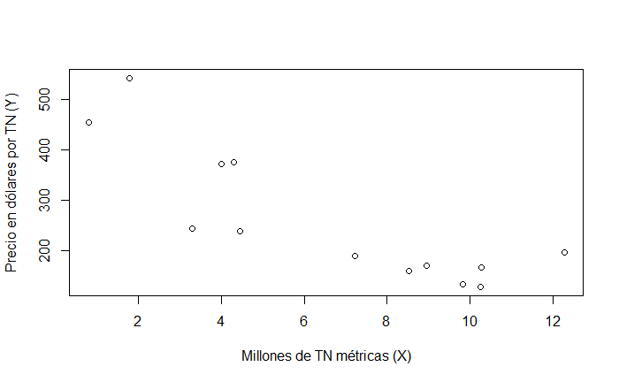

```r
plot(X, Y,
     ylab = "Precio en dólares por TN (Y)",
     xlab = "Millones de TN métricas (X)",

     )
```

En le gráfico se observa que las variables tienen relación inversa.

```r
help(plot)
```

## 1.3 Correlacion de los datos

```r
cor(Y,X)
```

```
[1] -0.8449331
```

La correlación entre la variables es alta e inversa.

## 1.4 Elaboracion del modelo

```r
modelo1 <- lm(Y ~ X)
summary(modelo1)
```

```
Call:
lm(formula = Y ~ X)

Residuals:
    Min      1Q  Median      3Q     Max
-115.60  -41.47  -16.38   32.70  135.15

Coefficients:
            Estimate Std. Error t value Pr(>|t|)
(Intercept)  461.006     43.585  10.577 4.21e-07 ***
X            -30.427      5.807  -5.239 0.000277 ***
---
Signif. codes:  0 ‘***’ 0.001 ‘**’ 0.01 ‘*’ 0.05 ‘.’ 0.1 ‘ ’ 1

Residual standard error: 74.28 on 11 degrees of freedom
Multiple R-squared:  0.7139,    Adjusted R-squared:  0.6879
F-statistic: 27.45 on 1 and 11 DF,  p-value: 0.0002771
```

α = 0.05  
Si el el p-valor (Pr(>|t|)) es menor que α, entonces los parámetros (β0,β1) son significativos.

```r
cor(Y,X)^2 # Solo cuando la regresión lineal es simple.
```

```
[1] 0.713912
```

## 1.5 Modelo de regresion lineal simple

**Modelo general**

$$Y = \beta_0 - \beta_1X$$

**Modelo hallado con los datos**

$$Y = 461.006 - 30.427 X$$

```r
y0 <- 461.006 - 30.427 * 0
y1 <- 461.006 - 30.427 * 1
y2 <- 461.006 - 30.427 * 2
```

```r
y2 - y1
```

```
[1] -30.427
```

**Analizando el Coeficiente de determinación** ($R^2$)

Multiple R-squared: 0.7139

**INTERPRETACION**: El 71.39% de la variación de los precioS (Y) es explicado por la variables captura en TM (X)

## 1.6 Grafica de los datos y el modelo generado

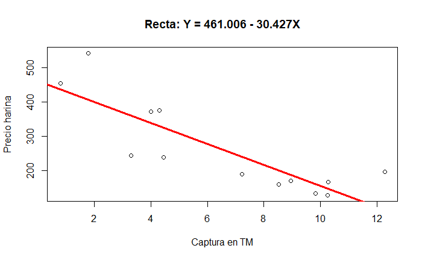

```r
plot(X, Y
    ,ylab = "Precio harina"
    ,xlab = "Captura en TM"
    ,main = "Recta: Y = 461.006 - 30.427X"
    )

abline(modelo1   # Agrega la recta
        ,col = "red"
        ,lwd = 3)
```

## 1.7 Analisis de los Errores

```r
Y_predecido = predict(modelo1) # Los valores de Y que están en la recta
Error = Y - Y_predecido
data.frame(X, Y, Y_predecido, Error)
```

|  | X | Y | Y_predecido | Error |
| --- | --- | --- | --- | --- |
| 1 | 7.23 | 190 | 241.02176 | -51.02176 |
| 2 | 8.53 | 160 | 201.46716 | -41.46716 |
| 3 | 9.82 | 134 | 162.21682 | -28.21682 |
| 4 | 10.26 | 129 | 148.82911 | -19.82911 |
| 5 | 8.96 | 172 | 188.38371 | -16.38371 |
| 6 | 12.27 | 197 | 87.67162 | 109.32838 |
| 7 | 10.28 | 167 | 148.22058 | 18.77942 |
| 8 | 4.45 | 239 | 325.60774 | -86.60774 |
| 9 | 1.78 | 542 | 406.84680 | 135.15320 |
| 10 | 4.00 | 372 | 339.29972 | 32.70028 |

[output cut: 3 more lines]

La suma de los errores deben ser igual a cero

```r
options(scipen = 999) #Elimina la notación científica decimal
sum(Error)
```

```
[1] -0.0000000000005400125
```

## 1.8 Prediccion con nuevos datos

$$Y = 461.006 - 30.427 X$$

```r
X_nuevos <- data.frame(X=c(5, 10, 15, 15.15, 50, 100))
Y_Prediccion <- predict(modelo1, X_nuevos)
data.frame(X_nuevos, Y_Prediccion)
```

|  | X | Y_Prediccion |
| --- | --- | --- |
| 1 | 5.00 | 308.87310567 |
| 2 | 10.00 | 156.74003282 |
| 3 | 15.00 | 4.60695996 |
| 4 | 15.15 | 0.04296778 |
| 5 | 50.00 | -1060.32455000 |
| 6 | 100.00 | -2581.65527853 |